# Risk Factor Analysis

## Outcome Variable

**Outcome Variable:** haz

## Predictor Variables

**Intervention Variable:** pers_wast

**Adjustment Set:**

- arm
- sex
- brthmon
- W_mage
- meducyrs
- hhwealth_quart
- W_nrooms
- month
- W_parity
- delta_W_mage
- delta_meducyrs
- delta_hhwealth_quart
- delta_W_nrooms
- delta_month
- delta_W_parity

## Stratifying Variables

The analysis was stratified on these variable(s):

- agecat
- studyid
- country

## Data Summary

| agecat | studyid | country | pers_wast | n_cell | n |
| --- | --- | --- | --- | --- | --- |
| Birth | ki0047075b-MAL-ED | BANGLADESH | 0 | 220 | 229 |
| Birth | ki0047075b-MAL-ED | BANGLADESH | 1 | 9 | 229 |
| Birth | ki0047075b-MAL-ED | BRAZIL | 0 | 65 | 65 |
| Birth | ki0047075b-MAL-ED | BRAZIL | 1 | 0 | 65 |
| Birth | ki0047075b-MAL-ED | INDIA | 0 | 43 | 45 |
| Birth | ki0047075b-MAL-ED | INDIA | 1 | 2 | 45 |
| Birth | ki0047075b-MAL-ED | NEPAL | 0 | 26 | 27 |
| Birth | ki0047075b-MAL-ED | NEPAL | 1 | 1 | 27 |
| Birth | ki0047075b-MAL-ED | PERU | 0 | 233 | 233 |
| Birth | ki0047075b-MAL-ED | PERU | 1 | 0 | 233 |
| Birth | ki0047075b-MAL-ED | SOUTH AFRICA | 0 | 111 | 113 |
| Birth | ki0047075b-MAL-ED | SOUTH AFRICA | 1 | 2 | 113 |
| Birth | ki0047075b-MAL-ED | TANZANIA, UNITED REPUBLIC OF | 0 | 123 | 123 |
| Birth | ki0047075b-MAL-ED | TANZANIA, UNITED REPUBLIC OF | 1 | 0 | 123 |
| Birth | ki1000108-CMC-V-BCS-2002 | INDIA | 0 | 80 | 92 |
| Birth | ki1000108-CMC-V-BCS-2002 | INDIA | 1 | 12 | 92 |
| Birth | ki1000108-IRC | INDIA | 0 | 319 | 387 |
| Birth | ki1000108-IRC | INDIA | 1 | 68 | 387 |
| Birth | ki1000109-EE | PAKISTAN | 0 | 224 | 240 |
| Birth | ki1000109-EE | PAKISTAN | 1 | 16 | 240 |
| Birth | ki1000109-ResPak | PAKISTAN | 0 | 30 | 34 |
| Birth | ki1000109-ResPak | PAKISTAN | 1 | 4 | 34 |
| Birth | ki1017093b-PROVIDE | BANGLADESH | 0 | 516 | 539 |
| Birth | ki1017093b-PROVIDE | BANGLADESH | 1 | 23 | 539 |
| Birth | ki1101329-Keneba | GAMBIA | 0 | 1374 | 1419 |
| Birth | ki1101329-Keneba | GAMBIA | 1 | 45 | 1419 |
| Birth | ki1113344-GMS-Nepal | NEPAL | 0 | 521 | 585 |
| Birth | ki1113344-GMS-Nepal | NEPAL | 1 | 64 | 585 |
| Birth | ki1114097-CMIN | BANGLADESH | 0 | 16 | 18 |
| Birth | ki1114097-CMIN | BANGLADESH | 1 | 2 | 18 |

[output cut: 70 more lines]

The following strata were considered:

- agecat: 24 months, studyid: ki0047075b-MAL-ED, country: BANGLADESH
- agecat: 24 months, studyid: ki0047075b-MAL-ED, country: BRAZIL
- agecat: 24 months, studyid: ki0047075b-MAL-ED, country: INDIA
- agecat: 24 months, studyid: ki0047075b-MAL-ED, country: NEPAL
- agecat: 24 months, studyid: ki0047075b-MAL-ED, country: PERU
- agecat: 24 months, studyid: ki0047075b-MAL-ED, country: SOUTH AFRICA
- agecat: 24 months, studyid: ki0047075b-MAL-ED, country: TANZANIA, UNITED REPUBLIC OF
- agecat: 24 months, studyid: ki1000108-CMC-V-BCS-2002, country: INDIA
- agecat: 24 months, studyid: ki1000108-IRC, country: INDIA
- agecat: 24 months, studyid: ki1000109-EE, country: PAKISTAN
- agecat: 24 months, studyid: ki1017093b-PROVIDE, country: BANGLADESH
- agecat: 24 months, studyid: ki1066203-TanzaniaChild2, country: TANZANIA, UNITED REPUBLIC OF
- agecat: 24 months, studyid: ki1101329-Keneba, country: GAMBIA
- agecat: 24 months, studyid: ki1113344-GMS-Nepal, country: NEPAL
- agecat: 24 months, studyid: ki1114097-CMIN, country: BANGLADESH
- agecat: 24 months, studyid: ki1114097-CONTENT, country: PERU
- agecat: 6 months, studyid: ki0047075b-MAL-ED, country: BANGLADESH
- agecat: 6 months, studyid: ki0047075b-MAL-ED, country: BRAZIL
- agecat: 6 months, studyid: ki0047075b-MAL-ED, country: INDIA
- agecat: 6 months, studyid: ki0047075b-MAL-ED, country: NEPAL
- agecat: 6 months, studyid: ki0047075b-MAL-ED, country: PERU
- agecat: 6 months, studyid: ki0047075b-MAL-ED, country: SOUTH AFRICA
- agecat: 6 months, studyid: ki0047075b-MAL-ED, country: TANZANIA, UNITED REPUBLIC OF
- agecat: 6 months, studyid: ki1000108-CMC-V-BCS-2002, country: INDIA
- agecat: 6 months, studyid: ki1000108-IRC, country: INDIA
- agecat: 6 months, studyid: ki1000109-EE, country: PAKISTAN
- agecat: 6 months, studyid: ki1000109-ResPak, country: PAKISTAN
- agecat: 6 months, studyid: ki1017093b-PROVIDE, country: BANGLADESH
- agecat: 6 months, studyid: ki1066203-TanzaniaChild2, country: TANZANIA, UNITED REPUBLIC OF
- agecat: 6 months, studyid: ki1101329-Keneba, country: GAMBIA
- agecat: 6 months, studyid: ki1112895-Guatemala BSC, country: GUATEMALA
- agecat: 6 months, studyid: ki1113344-GMS-Nepal, country: NEPAL
- agecat: 6 months, studyid: ki1114097-CMIN, country: BANGLADESH
- agecat: 6 months, studyid: ki1114097-CONTENT, country: PERU
- agecat: Birth, studyid: ki0047075b-MAL-ED, country: BANGLADESH
- agecat: Birth, studyid: ki0047075b-MAL-ED, country: BRAZIL
- agecat: Birth, studyid: ki0047075b-MAL-ED, country: INDIA
- agecat: Birth, studyid: ki0047075b-MAL-ED, country: NEPAL
- agecat: Birth, studyid: ki0047075b-MAL-ED, country: PERU
- agecat: Birth, studyid: ki0047075b-MAL-ED, country: SOUTH AFRICA
- agecat: Birth, studyid: ki0047075b-MAL-ED, country: TANZANIA, UNITED REPUBLIC OF
- agecat: Birth, studyid: ki1000108-CMC-V-BCS-2002, country: INDIA
- agecat: Birth, studyid: ki1000108-IRC, country: INDIA
- agecat: Birth, studyid: ki1000109-EE, country: PAKISTAN
- agecat: Birth, studyid: ki1000109-ResPak, country: PAKISTAN
- agecat: Birth, studyid: ki1017093b-PROVIDE, country: BANGLADESH
- agecat: Birth, studyid: ki1101329-Keneba, country: GAMBIA
- agecat: Birth, studyid: ki1113344-GMS-Nepal, country: NEPAL
- agecat: Birth, studyid: ki1114097-CMIN, country: BANGLADESH
- agecat: Birth, studyid: ki1114097-CONTENT, country: PERU

### Dropped Strata

Some strata were dropped due to rare outcomes:

- agecat: Birth, studyid: ki0047075b-MAL-ED, country: BRAZIL
- agecat: Birth, studyid: ki0047075b-MAL-ED, country: INDIA
- agecat: Birth, studyid: ki0047075b-MAL-ED, country: NEPAL
- agecat: Birth, studyid: ki0047075b-MAL-ED, country: PERU
- agecat: Birth, studyid: ki0047075b-MAL-ED, country: SOUTH AFRICA
- agecat: Birth, studyid: ki0047075b-MAL-ED, country: TANZANIA, UNITED REPUBLIC OF
- agecat: Birth, studyid: ki1000109-ResPak, country: PAKISTAN
- agecat: Birth, studyid: ki1114097-CMIN, country: BANGLADESH
- agecat: Birth, studyid: ki1114097-CONTENT, country: PERU
- agecat: 6 months, studyid: ki0047075b-MAL-ED, country: BRAZIL
- agecat: 6 months, studyid: ki0047075b-MAL-ED, country: PERU
- agecat: 6 months, studyid: ki0047075b-MAL-ED, country: SOUTH AFRICA
- agecat: 6 months, studyid: ki0047075b-MAL-ED, country: TANZANIA, UNITED REPUBLIC OF
- agecat: 6 months, studyid: ki1114097-CONTENT, country: PERU
- agecat: 24 months, studyid: ki0047075b-MAL-ED, country: BRAZIL
- agecat: 24 months, studyid: ki0047075b-MAL-ED, country: PERU
- agecat: 24 months, studyid: ki0047075b-MAL-ED, country: SOUTH AFRICA
- agecat: 24 months, studyid: ki0047075b-MAL-ED, country: TANZANIA, UNITED REPUBLIC OF
- agecat: 24 months, studyid: ki1066203-TanzaniaChild2, country: TANZANIA, UNITED REPUBLIC OF
- agecat: 24 months, studyid: ki1114097-CONTENT, country: PERU

## Methods Detail

We’re interested in the causal parameters $E[Y_a]$ for all values of $a \in \mathcal{A}$. These parameters represent the mean outcome if, possibly contrary to fact, we intervened to set all units to have $A=a$. Under the randomization and positivity assumptions, these are identified by the statistical parameters $\psi_a=E_W[E_{Y|A,W}(Y|A=a,W)]$. In addition, we’re interested in the mean of $Y$, $E[Y]$ under no intervention (the observed mean). We will estimate these parameters by using SuperLearner to fit the relevant likelihood factors – $E_{Y|A,W}(Y|A=a,W)$ and $p(A=a|W)$, and then updating our likelihood fit using a joint TMLE.

For unadjusted analyses ($W=\{\}$), initial likelihoods were estimated using Lrnr_glm to estimate the simple $E(Y|A)$ and Lrnr_mean to estimate $p(A)$. For adjusted analyses, a small library containing Lrnr_glmnet, Lrnr_xgboost, and Lrnr_mean was used.

Having estimated these parameters, we will then use the delta method to estimate relative risks and attributable risks relative to a prespecified baseline level of $A$.

# Results Detail

## Results Plots

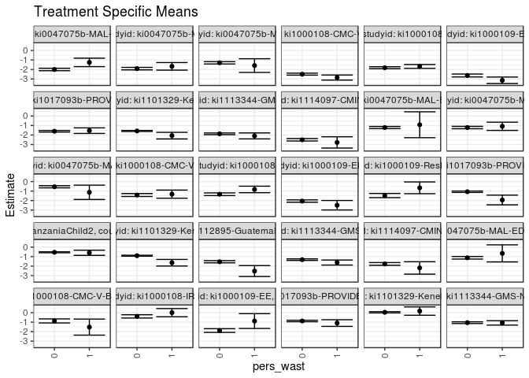

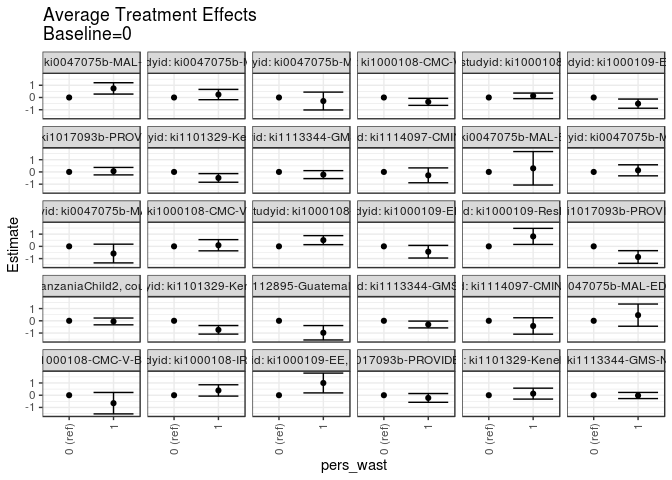

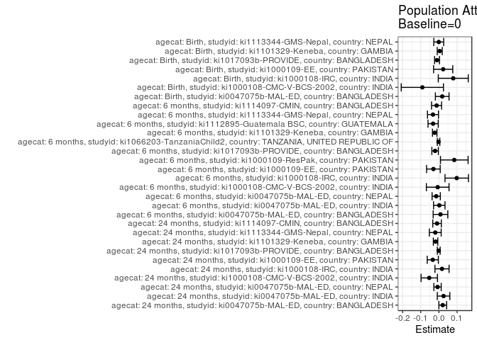

## Results Table

### Parameter: TSM

| agecat | studyid | country | intervention_level | baseline_level | estimate | ci_lower | ci_upper |
| --- | --- | --- | --- | --- | --- | --- | --- |
| Birth | ki0047075b-MAL-ED | BANGLADESH | 0 | NA | -1.1222727 | -1.2564846 | -0.9880609 |
| Birth | ki0047075b-MAL-ED | BANGLADESH | 1 | NA | -0.6600000 | -1.5592093 | 0.2392093 |
| Birth | ki1000108-CMC-V-BCS-2002 | INDIA | 0 | NA | -0.8699974 | -1.0835718 | -0.6564229 |
| Birth | ki1000108-CMC-V-BCS-2002 | INDIA | 1 | NA | -1.5211882 | -2.3690986 | -0.6732778 |
| Birth | ki1000108-IRC | INDIA | 0 | NA | -0.3906182 | -0.5629315 | -0.2183050 |
| Birth | ki1000108-IRC | INDIA | 1 | NA | 0.0001581 | -0.4299977 | 0.4303138 |
| Birth | ki1000109-EE | PAKISTAN | 0 | NA | -1.8843185 | -2.0785952 | -1.6900419 |
| Birth | ki1000109-EE | PAKISTAN | 1 | NA | -0.8841871 | -1.6643827 | -0.1039915 |
| Birth | ki1017093b-PROVIDE | BANGLADESH | 0 | NA | -0.8747810 | -0.9523389 | -0.7972230 |
| Birth | ki1017093b-PROVIDE | BANGLADESH | 1 | NA | -1.0953460 | -1.4447457 | -0.7459463 |
| Birth | ki1101329-Keneba | GAMBIA | 0 | NA | 0.0386765 | -0.0282236 | 0.1055766 |
| Birth | ki1101329-Keneba | GAMBIA | 1 | NA | 0.1685330 | -0.2717501 | 0.6088161 |
| Birth | ki1113344-GMS-Nepal | NEPAL | 0 | NA | -1.0545056 | -1.1463769 | -0.9626342 |
| Birth | ki1113344-GMS-Nepal | NEPAL | 1 | NA | -1.0787384 | -1.3120932 | -0.8453837 |
| 6 months | ki0047075b-MAL-ED | BANGLADESH | 0 | NA | -1.2135826 | -1.3270160 | -1.1001493 |
| 6 months | ki0047075b-MAL-ED | BANGLADESH | 1 | NA | -0.9178571 | -2.2823123 | 0.4465980 |
| 6 months | ki0047075b-MAL-ED | INDIA | 0 | NA | -1.2135127 | -1.3376326 | -1.0893928 |
| 6 months | ki0047075b-MAL-ED | INDIA | 1 | NA | -1.0816073 | -1.5155399 | -0.6476747 |
| 6 months | ki0047075b-MAL-ED | NEPAL | 0 | NA | -0.5467101 | -0.6599035 | -0.4335168 |
| 6 months | ki0047075b-MAL-ED | NEPAL | 1 | NA | -1.1316667 | -1.8892005 | -0.3741328 |
| 6 months | ki1000108-CMC-V-BCS-2002 | INDIA | 0 | NA | -1.4174852 | -1.5709734 | -1.2639969 |
| 6 months | ki1000108-CMC-V-BCS-2002 | INDIA | 1 | NA | -1.3253339 | -1.7530260 | -0.8976418 |
| 6 months | ki1000108-IRC | INDIA | 0 | NA | -1.3363143 | -1.4762316 | -1.1963969 |
| 6 months | ki1000108-IRC | INDIA | 1 | NA | -0.8290156 | -1.1716116 | -0.4864196 |
| 6 months | ki1000109-EE | PAKISTAN | 0 | NA | -2.0532111 | -2.1754449 | -1.9309772 |
| 6 months | ki1000109-EE | PAKISTAN | 1 | NA | -2.4914807 | -2.9934571 | -1.9895043 |
| 6 months | ki1000109-ResPak | PAKISTAN | 0 | NA | -1.4719913 | -1.6921595 | -1.2518230 |
| 6 months | ki1000109-ResPak | PAKISTAN | 1 | NA | -0.6576007 | -1.2767125 | -0.0384889 |
| 6 months | ki1017093b-PROVIDE | BANGLADESH | 0 | NA | -1.0706884 | -1.1452388 | -0.9961379 |
| 6 months | ki1017093b-PROVIDE | BANGLADESH | 1 | NA | -1.9400702 | -2.4531336 | -1.4270067 |
| 6 months | ki1066203-TanzaniaChild2 | TANZANIA, UNITED REPUBLIC OF | 0 | NA | -0.5431030 | -0.5930063 | -0.4931997 |
| 6 months | ki1066203-TanzaniaChild2 | TANZANIA, UNITED REPUBLIC OF | 1 | NA | -0.5952381 | -0.8687847 | -0.3216914 |
| 6 months | ki1101329-Keneba | GAMBIA | 0 | NA | -0.9049589 | -0.9538444 | -0.8560733 |
| 6 months | ki1101329-Keneba | GAMBIA | 1 | NA | -1.6430315 | -1.9892313 | -1.2968316 |
| 6 months | ki1112895-Guatemala BSC | GUATEMALA | 0 | NA | -1.5415418 | -1.6567941 | -1.4262896 |
| 6 months | ki1112895-Guatemala BSC | GUATEMALA | 1 | NA | -2.5211111 | -3.0985428 | -1.9436794 |
| 6 months | ki1113344-GMS-Nepal | NEPAL | 0 | NA | -1.3206073 | -1.4024071 | -1.2388075 |
| 6 months | ki1113344-GMS-Nepal | NEPAL | 1 | NA | -1.6246711 | -1.8900615 | -1.3592808 |
| 6 months | ki1114097-CMIN | BANGLADESH | 0 | NA | -1.7714847 | -1.9133246 | -1.6296449 |
| 6 months | ki1114097-CMIN | BANGLADESH | 1 | NA | -2.1944570 | -2.8488440 | -1.5400699 |
| 24 months | ki0047075b-MAL-ED | BANGLADESH | 0 | NA | -1.9994417 | -2.1279716 | -1.8709119 |
| 24 months | ki0047075b-MAL-ED | BANGLADESH | 1 | NA | -1.2558333 | -1.7012482 | -0.8104185 |
| 24 months | ki0047075b-MAL-ED | INDIA | 0 | NA | -1.9117038 | -2.0426111 | -1.7807965 |
| 24 months | ki0047075b-MAL-ED | INDIA | 1 | NA | -1.6707771 | -2.0704116 | -1.2711426 |
| 24 months | ki0047075b-MAL-ED | NEPAL | 0 | NA | -1.2999550 | -1.4209558 | -1.1789541 |
| 24 months | ki0047075b-MAL-ED | NEPAL | 1 | NA | -1.5900000 | -2.3102086 | -0.8697914 |
| 24 months | ki1000108-CMC-V-BCS-2002 | INDIA | 0 | NA | -2.4956834 | -2.6006873 | -2.3906794 |
| 24 months | ki1000108-CMC-V-BCS-2002 | INDIA | 1 | NA | -2.8517730 | -3.1202695 | -2.5832765 |
| 24 months | ki1000108-IRC | INDIA | 0 | NA | -1.8159607 | -1.9211357 | -1.7107857 |
| 24 months | ki1000108-IRC | INDIA | 1 | NA | -1.6803782 | -1.8812834 | -1.4794731 |
| 24 months | ki1000109-EE | PAKISTAN | 0 | NA | -2.6361627 | -2.7873261 | -2.4849994 |
| 24 months | ki1000109-EE | PAKISTAN | 1 | NA | -3.1398489 | -3.4819561 | -2.7977416 |
| 24 months | ki1017093b-PROVIDE | BANGLADESH | 0 | NA | -1.6014116 | -1.6865286 | -1.5162946 |
| 24 months | ki1017093b-PROVIDE | BANGLADESH | 1 | NA | -1.5385889 | -1.8318882 | -1.2452896 |
| 24 months | ki1101329-Keneba | GAMBIA | 0 | NA | -1.5737755 | -1.6280327 | -1.5195183 |
| 24 months | ki1101329-Keneba | GAMBIA | 1 | NA | -2.0636256 | -2.4113229 | -1.7159284 |
| 24 months | ki1113344-GMS-Nepal | NEPAL | 0 | NA | -1.8737413 | -1.9624917 | -1.7849908 |
| 24 months | ki1113344-GMS-Nepal | NEPAL | 1 | NA | -2.0945122 | -2.4083874 | -1.7806371 |
| 24 months | ki1114097-CMIN | BANGLADESH | 0 | NA | -2.5005794 | -2.6283894 | -2.3727694 |
| 24 months | ki1114097-CMIN | BANGLADESH | 1 | NA | -2.7794444 | -3.3734067 | -2.1854822 |

### Parameter: E(Y)

| agecat | studyid | country | intervention_level | baseline_level | estimate | ci_lower | ci_upper |
| --- | --- | --- | --- | --- | --- | --- | --- |
| Birth | ki0047075b-MAL-ED | BANGLADESH | NA | NA | -1.1041048 | -1.2383048 | -0.9699048 |
| Birth | ki1000108-CMC-V-BCS-2002 | INDIA | NA | NA | -0.9611957 | -1.1776967 | -0.7446946 |
| Birth | ki1000108-IRC | INDIA | NA | NA | -0.3117313 | -0.4727359 | -0.1507267 |
| Birth | ki1000109-EE | PAKISTAN | NA | NA | -1.8608750 | -2.0482045 | -1.6735455 |
| Birth | ki1017093b-PROVIDE | BANGLADESH | NA | NA | -0.8851020 | -0.9601332 | -0.8100709 |
| Birth | ki1101329-Keneba | GAMBIA | NA | NA | 0.0432135 | -0.0229516 | 0.1093787 |
| Birth | ki1113344-GMS-Nepal | NEPAL | NA | NA | -1.0554530 | -1.1411259 | -0.9697801 |
| 6 months | ki0047075b-MAL-ED | BANGLADESH | NA | NA | -1.2049931 | -1.3222136 | -1.0877726 |
| 6 months | ki0047075b-MAL-ED | INDIA | NA | NA | -1.2115254 | -1.3298727 | -1.0931782 |
| 6 months | ki0047075b-MAL-ED | NEPAL | NA | NA | -0.5615819 | -0.6741832 | -0.4489807 |
| 6 months | ki1000108-CMC-V-BCS-2002 | INDIA | NA | NA | -1.4241872 | -1.5668135 | -1.2815609 |
| 6 months | ki1000108-IRC | INDIA | NA | NA | -1.2382964 | -1.3698449 | -1.1067479 |
| 6 months | ki1000109-EE | PAKISTAN | NA | NA | -2.0835567 | -2.2027557 | -1.9643578 |
| 6 months | ki1000109-ResPak | PAKISTAN | NA | NA | -1.3874523 | -1.5959323 | -1.1789723 |
| 6 months | ki1017093b-PROVIDE | BANGLADESH | NA | NA | -1.0916915 | -1.1661176 | -1.0172654 |
| 6 months | ki1066203-TanzaniaChild2 | TANZANIA, UNITED REPUBLIC OF | NA | NA | -0.5450830 | -0.5941754 | -0.4959906 |
| 6 months | ki1101329-Keneba | GAMBIA | NA | NA | -0.9282048 | -0.9770928 | -0.8793169 |
| 6 months | ki1112895-Guatemala BSC | GUATEMALA | NA | NA | -1.5734843 | -1.6884116 | -1.4585570 |
| 6 months | ki1113344-GMS-Nepal | NEPAL | NA | NA | -1.3533244 | -1.4319426 | -1.2747062 |
| 6 months | ki1114097-CMIN | BANGLADESH | NA | NA | -1.7844376 | -1.9222926 | -1.6465825 |
| 24 months | ki0047075b-MAL-ED | BANGLADESH | NA | NA | -1.9783962 | -2.1050210 | -1.8517715 |
| 24 months | ki0047075b-MAL-ED | INDIA | NA | NA | -1.8861894 | -2.0110006 | -1.7613783 |
| 24 months | ki0047075b-MAL-ED | NEPAL | NA | NA | -1.3075877 | -1.4270718 | -1.1881037 |
| 24 months | ki1000108-CMC-V-BCS-2002 | INDIA | NA | NA | -2.5489071 | -2.6476125 | -2.4502017 |
| 24 months | ki1000108-IRC | INDIA | NA | NA | -1.7989338 | -1.8927769 | -1.7050907 |
| 24 months | ki1000109-EE | PAKISTAN | NA | NA | -2.6699900 | -2.8138051 | -2.5261749 |
| 24 months | ki1017093b-PROVIDE | BANGLADESH | NA | NA | -1.6024221 | -1.6857420 | -1.5191023 |
| 24 months | ki1101329-Keneba | GAMBIA | NA | NA | -1.5924094 | -1.6461889 | -1.5386298 |
| 24 months | ki1113344-GMS-Nepal | NEPAL | NA | NA | -1.8938622 | -1.9795205 | -1.8082040 |
| 24 months | ki1114097-CMIN | BANGLADESH | NA | NA | -2.5109504 | -2.6361514 | -2.3857494 |

### Parameter: ATE

| agecat | studyid | country | intervention_level | baseline_level | estimate | ci_lower | ci_upper |
| --- | --- | --- | --- | --- | --- | --- | --- |
| Birth | ki0047075b-MAL-ED | BANGLADESH | 0 | 0 | 0.0000000 | 0.0000000 | 0.0000000 |
| Birth | ki0047075b-MAL-ED | BANGLADESH | 1 | 0 | 0.4622727 | -0.4468973 | 1.3714428 |
| Birth | ki1000108-CMC-V-BCS-2002 | INDIA | 0 | 0 | 0.0000000 | 0.0000000 | 0.0000000 |
| Birth | ki1000108-CMC-V-BCS-2002 | INDIA | 1 | 0 | -0.6511908 | -1.5278060 | 0.2254244 |
| Birth | ki1000108-IRC | INDIA | 0 | 0 | 0.0000000 | 0.0000000 | 0.0000000 |
| Birth | ki1000108-IRC | INDIA | 1 | 0 | 0.3907763 | -0.0727948 | 0.8543474 |
| Birth | ki1000109-EE | PAKISTAN | 0 | 0 | 0.0000000 | 0.0000000 | 0.0000000 |
| Birth | ki1000109-EE | PAKISTAN | 1 | 0 | 1.0001314 | 0.1913820 | 1.8088808 |
| Birth | ki1017093b-PROVIDE | BANGLADESH | 0 | 0 | 0.0000000 | 0.0000000 | 0.0000000 |
| Birth | ki1017093b-PROVIDE | BANGLADESH | 1 | 0 | -0.2205650 | -0.5780526 | 0.1369225 |
| Birth | ki1101329-Keneba | GAMBIA | 0 | 0 | 0.0000000 | 0.0000000 | 0.0000000 |
| Birth | ki1101329-Keneba | GAMBIA | 1 | 0 | 0.1298565 | -0.3156369 | 0.5753499 |
| Birth | ki1113344-GMS-Nepal | NEPAL | 0 | 0 | 0.0000000 | 0.0000000 | 0.0000000 |
| Birth | ki1113344-GMS-Nepal | NEPAL | 1 | 0 | -0.0242329 | -0.2749338 | 0.2264680 |
| 6 months | ki0047075b-MAL-ED | BANGLADESH | 0 | 0 | 0.0000000 | 0.0000000 | 0.0000000 |
| 6 months | ki0047075b-MAL-ED | BANGLADESH | 1 | 0 | 0.2957255 | -1.0734367 | 1.6648877 |
| 6 months | ki0047075b-MAL-ED | INDIA | 0 | 0 | 0.0000000 | 0.0000000 | 0.0000000 |
| 6 months | ki0047075b-MAL-ED | INDIA | 1 | 0 | 0.1319054 | -0.3200226 | 0.5838333 |
| 6 months | ki0047075b-MAL-ED | NEPAL | 0 | 0 | 0.0000000 | 0.0000000 | 0.0000000 |
| 6 months | ki0047075b-MAL-ED | NEPAL | 1 | 0 | -0.5849565 | -1.3509005 | 0.1809875 |
| 6 months | ki1000108-CMC-V-BCS-2002 | INDIA | 0 | 0 | 0.0000000 | 0.0000000 | 0.0000000 |
| 6 months | ki1000108-CMC-V-BCS-2002 | INDIA | 1 | 0 | 0.0921512 | -0.3642388 | 0.5485413 |
| 6 months | ki1000108-IRC | INDIA | 0 | 0 | 0.0000000 | 0.0000000 | 0.0000000 |
| 6 months | ki1000108-IRC | INDIA | 1 | 0 | 0.5072987 | 0.1388356 | 0.8757618 |
| 6 months | ki1000109-EE | PAKISTAN | 0 | 0 | 0.0000000 | 0.0000000 | 0.0000000 |
| 6 months | ki1000109-EE | PAKISTAN | 1 | 0 | -0.4382696 | -0.9552601 | 0.0787208 |
| 6 months | ki1000109-ResPak | PAKISTAN | 0 | 0 | 0.0000000 | 0.0000000 | 0.0000000 |
| 6 months | ki1000109-ResPak | PAKISTAN | 1 | 0 | 0.8143906 | 0.1572499 | 1.4715312 |
| 6 months | ki1017093b-PROVIDE | BANGLADESH | 0 | 0 | 0.0000000 | 0.0000000 | 0.0000000 |
| 6 months | ki1017093b-PROVIDE | BANGLADESH | 1 | 0 | -0.8693818 | -1.3874503 | -0.3513133 |
| 6 months | ki1066203-TanzaniaChild2 | TANZANIA, UNITED REPUBLIC OF | 0 | 0 | 0.0000000 | 0.0000000 | 0.0000000 |
| 6 months | ki1066203-TanzaniaChild2 | TANZANIA, UNITED REPUBLIC OF | 1 | 0 | -0.0521350 | -0.3301902 | 0.2259202 |
| 6 months | ki1101329-Keneba | GAMBIA | 0 | 0 | 0.0000000 | 0.0000000 | 0.0000000 |
| 6 months | ki1101329-Keneba | GAMBIA | 1 | 0 | -0.7380726 | -1.0878405 | -0.3883048 |
| 6 months | ki1112895-Guatemala BSC | GUATEMALA | 0 | 0 | 0.0000000 | 0.0000000 | 0.0000000 |
| 6 months | ki1112895-Guatemala BSC | GUATEMALA | 1 | 0 | -0.9795693 | -1.5683905 | -0.3907481 |
| 6 months | ki1113344-GMS-Nepal | NEPAL | 0 | 0 | 0.0000000 | 0.0000000 | 0.0000000 |
| 6 months | ki1113344-GMS-Nepal | NEPAL | 1 | 0 | -0.3040639 | -0.5818334 | -0.0262943 |
| 6 months | ki1114097-CMIN | BANGLADESH | 0 | 0 | 0.0000000 | 0.0000000 | 0.0000000 |
| 6 months | ki1114097-CMIN | BANGLADESH | 1 | 0 | -0.4229723 | -1.0927713 | 0.2468268 |
| 24 months | ki0047075b-MAL-ED | BANGLADESH | 0 | 0 | 0.0000000 | 0.0000000 | 0.0000000 |
| 24 months | ki0047075b-MAL-ED | BANGLADESH | 1 | 0 | 0.7436084 | 0.2800199 | 1.2071969 |
| 24 months | ki0047075b-MAL-ED | INDIA | 0 | 0 | 0.0000000 | 0.0000000 | 0.0000000 |
| 24 months | ki0047075b-MAL-ED | INDIA | 1 | 0 | 0.2409267 | -0.1803150 | 0.6621684 |
| 24 months | ki0047075b-MAL-ED | NEPAL | 0 | 0 | 0.0000000 | 0.0000000 | 0.0000000 |
| 24 months | ki0047075b-MAL-ED | NEPAL | 1 | 0 | -0.2900450 | -1.0203475 | 0.4402574 |
| 24 months | ki1000108-CMC-V-BCS-2002 | INDIA | 0 | 0 | 0.0000000 | 0.0000000 | 0.0000000 |
| 24 months | ki1000108-CMC-V-BCS-2002 | INDIA | 1 | 0 | -0.3560896 | -0.6445027 | -0.0676766 |
| 24 months | ki1000108-IRC | INDIA | 0 | 0 | 0.0000000 | 0.0000000 | 0.0000000 |
| 24 months | ki1000108-IRC | INDIA | 1 | 0 | 0.1355825 | -0.0913063 | 0.3624712 |
| 24 months | ki1000109-EE | PAKISTAN | 0 | 0 | 0.0000000 | 0.0000000 | 0.0000000 |
| 24 months | ki1000109-EE | PAKISTAN | 1 | 0 | -0.5036861 | -0.8787388 | -0.1286334 |
| 24 months | ki1017093b-PROVIDE | BANGLADESH | 0 | 0 | 0.0000000 | 0.0000000 | 0.0000000 |
| 24 months | ki1017093b-PROVIDE | BANGLADESH | 1 | 0 | 0.0628227 | -0.2427150 | 0.3683603 |
| 24 months | ki1101329-Keneba | GAMBIA | 0 | 0 | 0.0000000 | 0.0000000 | 0.0000000 |
| 24 months | ki1101329-Keneba | GAMBIA | 1 | 0 | -0.4898502 | -0.8421163 | -0.1375840 |
| 24 months | ki1113344-GMS-Nepal | NEPAL | 0 | 0 | 0.0000000 | 0.0000000 | 0.0000000 |
| 24 months | ki1113344-GMS-Nepal | NEPAL | 1 | 0 | -0.2207710 | -0.5464499 | 0.1049080 |
| 24 months | ki1114097-CMIN | BANGLADESH | 0 | 0 | 0.0000000 | 0.0000000 | 0.0000000 |
| 24 months | ki1114097-CMIN | BANGLADESH | 1 | 0 | -0.2788650 | -0.8864229 | 0.3286928 |

### Parameter: PAR

| agecat | studyid | country | intervention_level | baseline_level | estimate | ci_lower | ci_upper |
| --- | --- | --- | --- | --- | --- | --- | --- |
| Birth | ki0047075b-MAL-ED | BANGLADESH | 0 | NA | 0.0181679 | -0.0194178 | 0.0557537 |
| Birth | ki1000108-CMC-V-BCS-2002 | INDIA | 0 | NA | -0.0911983 | -0.2073393 | 0.0249428 |
| Birth | ki1000108-IRC | INDIA | 0 | NA | 0.0788870 | -0.0035806 | 0.1613545 |
| Birth | ki1000109-EE | PAKISTAN | 0 | NA | 0.0234435 | -0.0292919 | 0.0761789 |
| Birth | ki1017093b-PROVIDE | BANGLADESH | 0 | NA | -0.0103211 | -0.0239562 | 0.0033141 |
| Birth | ki1101329-Keneba | GAMBIA | 0 | NA | 0.0045370 | -0.0092205 | 0.0182945 |
| Birth | ki1113344-GMS-Nepal | NEPAL | 0 | NA | -0.0009474 | -0.0281602 | 0.0262653 |
| 6 months | ki0047075b-MAL-ED | BANGLADESH | 0 | NA | 0.0085895 | -0.0316719 | 0.0488510 |
| 6 months | ki0047075b-MAL-ED | INDIA | 0 | NA | 0.0019873 | -0.0294706 | 0.0334451 |
| 6 months | ki0047075b-MAL-ED | NEPAL | 0 | NA | -0.0148718 | -0.0376268 | 0.0078833 |
| 6 months | ki1000108-CMC-V-BCS-2002 | INDIA | 0 | NA | -0.0067020 | -0.0690657 | 0.0556617 |
| 6 months | ki1000108-IRC | INDIA | 0 | NA | 0.0980179 | 0.0335279 | 0.1625079 |
| 6 months | ki1000109-EE | PAKISTAN | 0 | NA | -0.0303457 | -0.0678887 | 0.0071973 |
| 6 months | ki1000109-ResPak | PAKISTAN | 0 | NA | 0.0845390 | 0.0085331 | 0.1605449 |
| 6 months | ki1017093b-PROVIDE | BANGLADESH | 0 | NA | -0.0210031 | -0.0388111 | -0.0031952 |
| 6 months | ki1066203-TanzaniaChild2 | TANZANIA, UNITED REPUBLIC OF | 0 | NA | -0.0019799 | -0.0088616 | 0.0049017 |
| 6 months | ki1101329-Keneba | GAMBIA | 0 | NA | -0.0232460 | -0.0356321 | -0.0108599 |
| 6 months | ki1112895-Guatemala BSC | GUATEMALA | 0 | NA | -0.0319425 | -0.0600761 | -0.0038089 |
| 6 months | ki1113344-GMS-Nepal | NEPAL | 0 | NA | -0.0327171 | -0.0630544 | -0.0023798 |
| 6 months | ki1114097-CMIN | BANGLADESH | 0 | NA | -0.0129529 | -0.0405876 | 0.0146818 |
| 24 months | ki0047075b-MAL-ED | BANGLADESH | 0 | NA | 0.0210455 | -0.0001441 | 0.0422351 |
| 24 months | ki0047075b-MAL-ED | INDIA | 0 | NA | 0.0255143 | -0.0090472 | 0.0600759 |
| 24 months | ki0047075b-MAL-ED | NEPAL | 0 | NA | -0.0076328 | -0.0277780 | 0.0125124 |
| 24 months | ki1000108-CMC-V-BCS-2002 | INDIA | 0 | NA | -0.0532237 | -0.0982869 | -0.0081605 |
| 24 months | ki1000108-IRC | INDIA | 0 | NA | 0.0170269 | -0.0218401 | 0.0558939 |
| 24 months | ki1000109-EE | PAKISTAN | 0 | NA | -0.0338273 | -0.0644077 | -0.0032468 |
| 24 months | ki1017093b-PROVIDE | BANGLADESH | 0 | NA | -0.0010106 | -0.0088087 | 0.0067876 |
| 24 months | ki1101329-Keneba | GAMBIA | 0 | NA | -0.0186339 | -0.0307903 | -0.0064775 |
| 24 months | ki1113344-GMS-Nepal | NEPAL | 0 | NA | -0.0201210 | -0.0526016 | 0.0123597 |
| 24 months | ki1114097-CMIN | BANGLADESH | 0 | NA | -0.0103710 | -0.0339279 | 0.0131858 |